# Instrumental Variables with STAN

# What is this?

I don’t think `brms` is really set up for the kinds of models we will ultimately need to fit, namely nonlinear instrumental variables models. It looks like we will need to bite the bullet and learn STAN. Unfortunately the only example of IV estimation with STAN that I could find online was [this tutorial](https://khakieconomics.github.io/2017/11/26/Bayesian_iv.html). While helpful, it’s a bit complicated and I want to start with the very basics. Here I work through the xample from Section 14.3 of [Statistical Rethinking](https://xcelab.net/rm/statistical-rethinking/) using the `ulam()` command from the [`rethinking` package](https://github.com/rmcelreath/rethinking). I then extract the underlying STAN code.

# First just run it verbatim

This is lifted directly from the book. Below I’ll modify and extend. What is the causal effect of education $E$ on wages $W$? An unobserved confounder $U$ (ability) causes both $E$ and $W$ but fortunately we have a valid instrument $Q$ (quarter of birth).

## Simulate data

In the simulation, the causal effect of $E$ on $W$ is zero and everything is standardized. (Why? I think he talks about this earlier in the book and that it helps with setting up priors in a reasonable way.)

```r
library(rethinking)
set.seed(73)
N <- 500
U_sim <- rnorm(N)
Q_sim <- sample(1:4, size = N, replace = TRUE) # quarter of birth
E_sim <- rnorm(N, U_sim + Q_sim) # education
W_sim <- rnorm(N, U_sim + 0 * E_sim) # wage
dat_sim <- list(
  W = standardize(W_sim),
  E = standardize(E_sim),
  Q = standardize(Q_sim)
)
```

## First Model: OLS

```r
m14.4 <- ulam(
  alist(
    W ~ dnorm(mu, sigma),
    mu <- aW + bEW * E,
    aW ~ dnorm(0, 0.2),
    bEW ~ dnorm(0, 0.5),
    sigma ~ dexp(1)),
  data = dat_sim, chains = 4, cores = 4)
```

[output not shown]

[output not shown]

[output not shown]

[output not shown]

[output not shown]

[output not shown]

[output not shown]

[output not shown]

[output not shown]

[output not shown]

[output not shown]

[output not shown]

[output not shown]

```r
precis(m14.4)
```

```
               mean         sd        5.5%      94.5%    n_eff     Rhat4
aW    -0.0006373815 0.04036694 -0.06392666 0.06371642 2003.031 1.0001334
bEW    0.3983583860 0.04055542  0.33354329 0.46103450 2077.047 1.0014770
sigma  0.9187746380 0.02836789  0.87339397 0.96360186 2053.195 0.9992395
```

## Second Model: Instrument as a Bad Control

```r
m14.5 <- ulam(
  alist(
    W ~ dnorm(mu, sigma),
    mu <- aW + bEW * E + bQW * Q,
    aW ~ dnorm(0, 0.2),
    bEW ~ dnorm(0, 0.5),
    bQW ~ dnorm(0, 0.5),
    sigma ~ dexp(1)),
  data = dat_sim, chains = 4, cores = 4)
```

[output not shown]

```r
precis(m14.5)
```

```
               mean         sd        5.5%       94.5%    n_eff     Rhat4
aW    -0.0001130208 0.03849200 -0.06112274  0.06229007 1531.511 1.0026919
bEW    0.6334389820 0.04724754  0.55831404  0.70748331 1438.686 1.0033298
bQW   -0.4034072005 0.04809581 -0.48151201 -0.32860244 1449.380 1.0019965
sigma  0.8571140075 0.02747099  0.81318688  0.90155981 2172.168 0.9996443
```

## Third Model: Instrumental Variables

```r
m14.6 <- ulam(
  alist(
    c(W, E) ~ multi_normal(c(muW, muE), Rho, Sigma),
    muW <- aW + bEW * E,
    muE <- aE + bQE * Q,
    c(aW, aE) ~ normal(0, 0.2), # indep priors
    c(bEW, bQE) ~ normal(0, 0.5), # indep priors
    Rho ~ lkj_corr(2),
    Sigma ~ exponential(1)),
  data = dat_sim, chains = 4, cores = 4)
```

[output not shown]

```r
precis(m14.6, depth = 3)
```

```
                  mean         sd        5.5%      94.5%     n_eff     Rhat4
aE       -0.0004069066 0.03697113 -0.05760392 0.05975111 1555.3301 0.9996272
aW       -0.0002298111 0.04518601 -0.07132140 0.07167898 1550.9579 0.9994834
bQE       0.5876216410 0.03540682  0.53159823 0.64387507 1225.5922 1.0008337
bEW      -0.0512234866 0.07840308 -0.18239745 0.07035524  817.0910 1.0031648
Rho[1,1]  1.0000000000 0.00000000  1.00000000 1.00000000       NaN       NaN
Rho[1,2]  0.5432378985 0.05453228  0.45329179 0.62833055  835.5219 1.0049687
Rho[2,1]  0.5432378985 0.05453228  0.45329179 0.62833055  835.5219 1.0049687
Rho[2,2]  1.0000000000 0.00000000  1.00000000 1.00000000       NaN       NaN
Sigma[1]  1.0259460345 0.04812868  0.95186388 1.10565825  908.4399 1.0045550
Sigma[2]  0.8084085625 0.02597389  0.76555061 0.85137286 1648.9666 1.0009472
```

## Sample From the IV Prior

```r
m14.6_prior <- extract.prior(m14.6)
```

[output not shown]

```r
str(m14.6_prior)
```

```
List of 6
 $ aE   : num [1:1000(1d)] 0.0301 -0.1528 0.0346 0.163 -0.2747 ...
 $ aW   : num [1:1000(1d)] -0.08974 -0.10252 -0.15924 -0.00744 0.08435 ...
 $ bQE  : num [1:1000(1d)] -0.0763 0.2471 -0.7316 1.0942 -0.9221 ...
 $ bEW  : num [1:1000(1d)] 0.3183 0.1448 -0.0499 -0.1708 -0.026 ...
 $ Rho  : num [1:1000] 1 1 1 1 1 1 1 1 1 1 ...
 $ Sigma: num [1:1000(1d)] 0.638 0.325 5.552 1.763 1.548 ...
 - attr(*, "source")= chr "ulam prior: 1000 samples from fit"
```

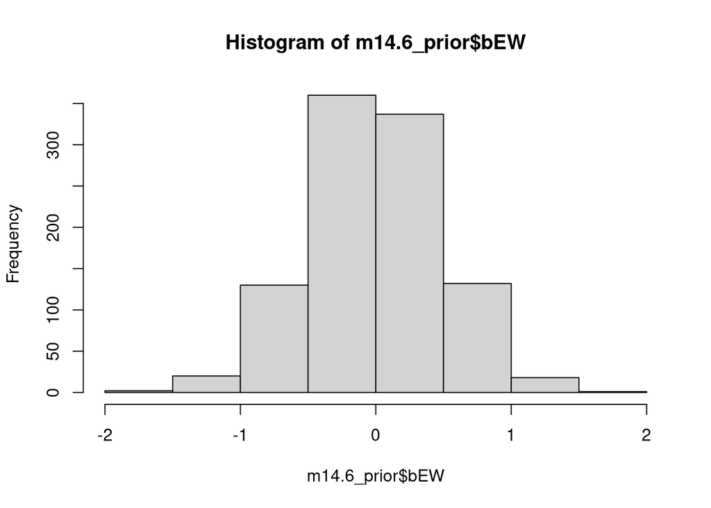

```r
hist(m14.6_prior$bEW)
```

## Prior Predictive Simulations

Supposedly we can use the `link()` function but I’m a bit confused. The question is what data we need to supply. I think it should only be the instrument, but somehow it’s expecting us to provide the regressor as well. Also, it only seems to simulate the means of $W$ and $E$. I need to think a bit more about this

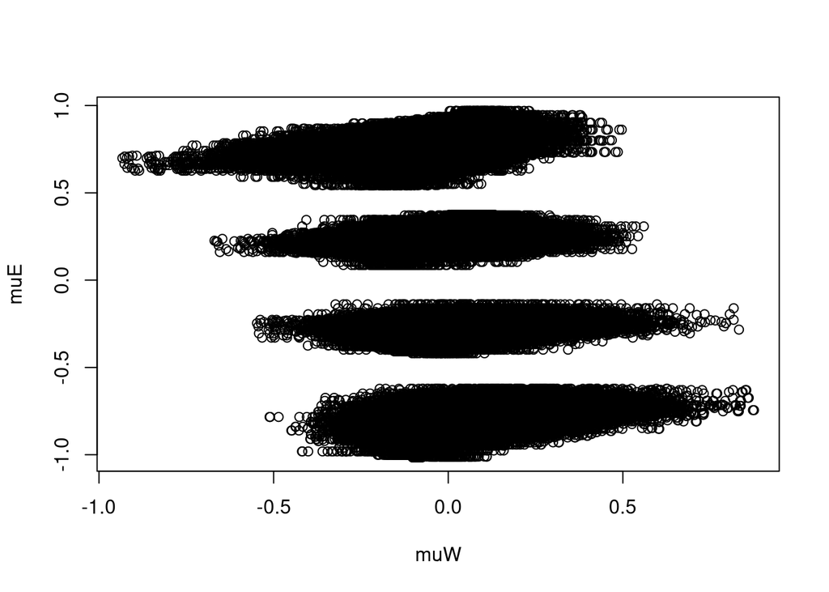

```r
prior_pred <- link(m14.6, data = list(Q = standardize(Q_sim),
                                      E = standardize(E_sim)))
with(prior_pred, plot(muW, muE))
```

## Sample from the IV Posterior

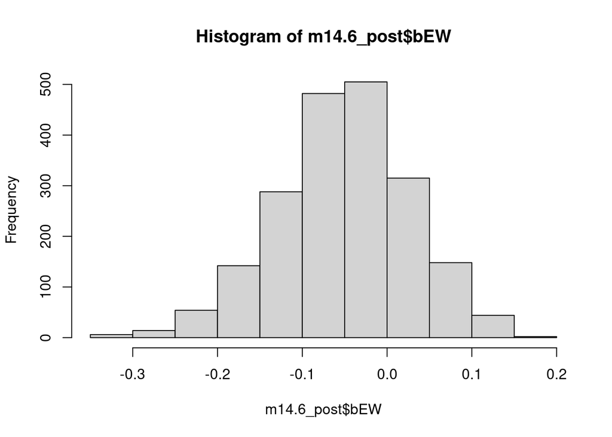

```r
m14.6_post <- extract.samples(m14.6)
hist(m14.6_post$bEW)
```

## Extract the underlying STAN code

```r
stancode(m14.6)
```

```
data{
     vector[500] W;
     vector[500] E;
     vector[500] Q;
}
parameters{
     real aE;
     real aW;
     real bQE;
     real bEW;
     corr_matrix[2] Rho;
     vector<lower=0>[2] Sigma;
}
model{
     vector[500] muW;
     vector[500] muE;
    Sigma ~ exponential( 1 );
    Rho ~ lkj_corr( 2 );
    bEW ~ normal( 0 , 0.5 );
    bQE ~ normal( 0 , 0.5 );
    aW ~ normal( 0 , 0.2 );
    aE ~ normal( 0 , 0.2 );
    for ( i in 1:500 ) {
        muE[i] = aE + bQE * Q[i];
    }
    for ( i in 1:500 ) {
        muW[i] = aW + bEW * E[i];
    }
    {
    array[500] vector[2] YY;
    array[500] vector[2] MU;
    for ( j in 1:500 ) MU[j] = [ muW[j] , muE[j] ]';
    for ( j in 1:500 ) YY[j] = [ W[j] , E[j] ]';
    YY ~ multi_normal( MU , quad_form_diag(Rho , Sigma) );
    }
}
```